# Analyzing Sleep Health and Lifestyle: Key Insights and Challenges

# QUESTIONS:

# 1. How do physical activity levels correlate with the quality of sleep?

# To examine the correlation between physical activity levels and quality of sleep, we can use the cor() function

# or create a scatter plot. Here’s how youwe can modify the code to answer this question:

```r
# Add a Correlation and Scatter Plot:
# Calculate correlation
correlation_physical_activity_sleep <- cor(dataset$PhysicalActivity, dataset$QualityOfSleep)
print(paste("Correlation between Physical Activity and Quality of Sleep:", correlation_physical_activity_sleep))
```

```
[1] "Correlation between Physical Activity and Quality of Sleep: 0.192896454939753"
```

The correlation value between Physical Activity and Quality of Sleep is 0.1929, which indicates a very weak positive correlation. This means that while there is a slight tendency for individuals with higher physical activity levels to have better sleep quality, the relationship is not strong. Essentially, physical activity has a minor effect on sleep quality based on this dataset.

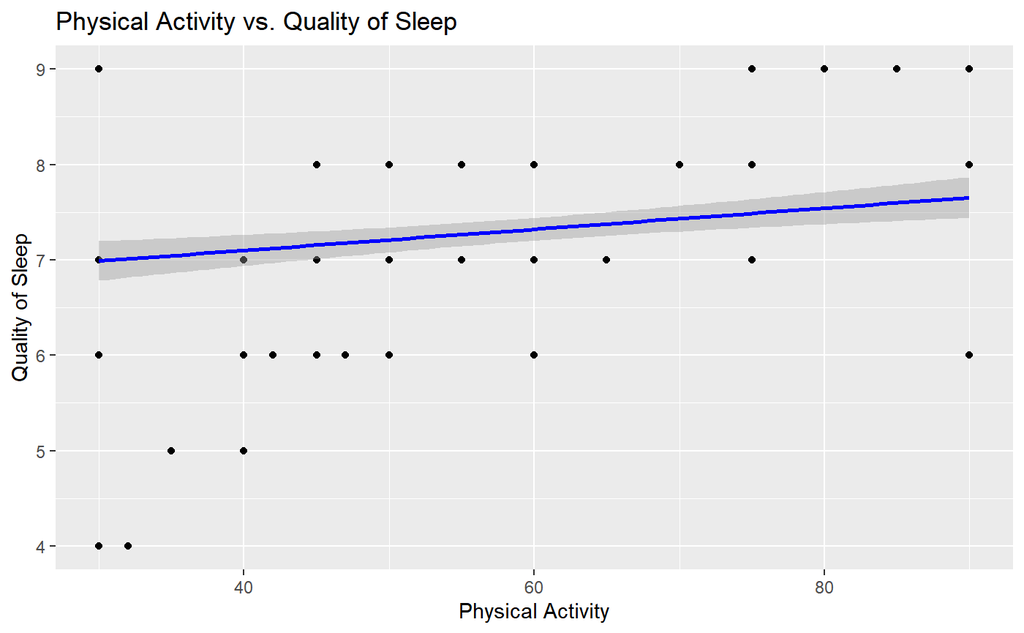

```r
# Scatter plot
ggplot(dataset, aes(x = PhysicalActivity, y = QualityOfSleep)) +
  geom_point() +
  geom_smooth(method = "lm", col = "blue") +
  labs(title = "Physical Activity vs. Quality of Sleep", x = "Physical Activity", y = "Quality of Sleep")
```

# ——————————————————-

# 2. Does stress level impact sleep duration?

# Similarly, we can calculate the correlation between stress levels and sleep duration or visualize this relationship with a scatter plot:

```r
# Calculate correlation
correlation_stress_sleep <- cor(dataset$StressLevel, dataset$SleepDuration)
print(paste("Correlation between Stress Level and Sleep Duration:", correlation_stress_sleep))
```

```
[1] "Correlation between Stress Level and Sleep Duration: -0.811023027894043"
```

The correlation between Stress Level and Sleep Duration is -0.8110, which indicates a strong negative correlation. This means that as stress levels increase, sleep duration tends to decrease significantly. In other words, higher stress is strongly associated with shorter sleep duration in this dataset.

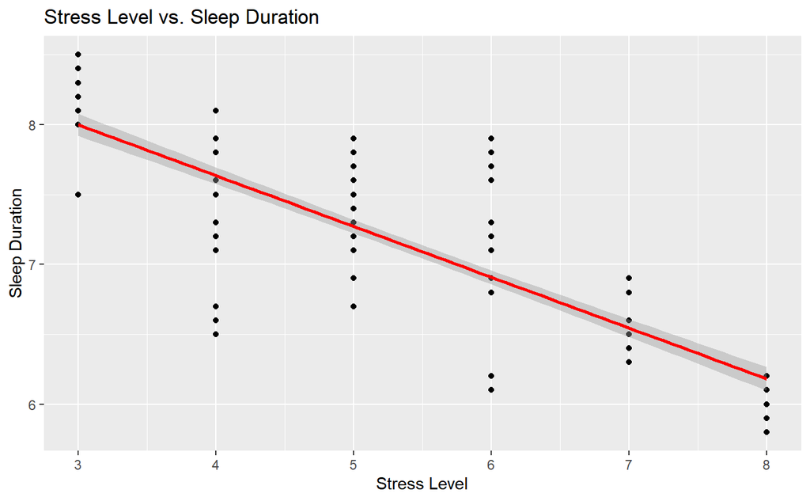

```r
# Scatter plot
ggplot(dataset, aes(x = StressLevel, y = SleepDuration)) +
  geom_point() +
  geom_smooth(method = "lm", col = "red") +
  labs(title = "Stress Level vs. Sleep Duration", x = "Stress Level", y = "Sleep Duration")
```